# 3 **Molecules, Water, and pH**

## 3.1 **Pre-Lab Activity 3.1: Questions**

> **Objectives**
1. Represent molecules using molecular models
2. Write a molecular formula based on a structural formula
3. Identify and demonstrate various properties of water that make it essential for life.
4. Identify acids and bases and learn how to measure their pH
5. Identify the role of buffers in living organisms

> **Short Answer (10)**
11. Define an organic molecule. has carbon and hydrogen
12. What is a covalent bond? shares electrons
13. What is the difference between a molecular and structural formula? molecular: written as CH4 Structural: visual representation of the molecule
14. What does the formula C₂H₆O tell you about a molecule? organic molecule, ethanol (if we look at it)
15. What is a functional group? methyl, carboxyl, amino, (6 total groups)
16. Explain what an isomer is. same moleculular formula, diff structure and function(?)
17. Why is water considered an excellent solvent? it’s polar – dissolves many things except hydrophobic things
18. Define cohesion and adhesion. Water sticking to itself (cohesion) Water sticking to other surfaces (adhesion)
19. What is surface tension? To break water’s surface, you must break water’s cohesion.
20. Why is pH important in living organisms? Can’t have reaction occur if pH is imbalanced

> **Key Terms to Define**
- Organic compound
- Inorganic compound
- Covalent bond
- Molecular formula
- Structural formula
- Abbreviated structural formula
- Isomer
- Polarity
- pH
- Acid
- Base
- Buffer

## 3.2 **Introduction: Molecules, Water, and pH**

> Biology is the study of life, and understanding life begins with understanding the chemistry that makes it possible. In this first-semester biology lab, you will explore the fundamental chemical principles that underlie biological systems, preparing you for advanced work as a biology major or pre-med student. Through hands-on experiments and model-based activities, you will connect basic chemical concepts to real biological function.

> Chemical compounds can be divided into two broad categories: **inorganic** and **organic**. Inorganic compounds, such as water, salts, acids, and bases, generally do not contain carbon–hydrogen (C–H) bonds and play essential roles in maintaining life processes. Organic molecules, on the other hand, are defined by the presence of carbon and C–H bonds. Carbon’s unique ability to form four covalent bonds allows it to create a wide variety of complex molecules, especially when combined with other key elements such as oxygen, nitrogen, phosphorus, and sulfur—elements that make up the vast majority of living matter.

> In this lab, you will investigate how atoms form **molecules** through **covalent bonding**, where electrons are shared between atoms. You will learn how to represent molecules using **molecular formulas**, **structural formulas**, and **abbreviated structural formulas**, each providing different levels of detail. Using molecular model kits, you will build three-dimensional representations of molecules to better understand how atomic arrangement influences molecular shape and function. You will also explore **isomers**, which are molecules with the same molecular formula but different structures, demonstrating how small differences in arrangement can lead to significant biological differences.

> A major focus of this lab is **water**, one of the most important inorganic molecules for life. Because of its polar structure, water exhibits unique properties such as cohesion, adhesion, high surface tension, and high specific heat. These properties allow water to act as a solvent, regulate temperature, and move through narrow spaces via capillary action—all essential for sustaining life. You will perform experiments to observe and measure these properties directly.

> You will also examine **acids, bases, and pH**, which are critical for maintaining proper conditions in biological systems. The pH scale measures the concentration of hydrogen ions in a solution and determines whether a solution is acidic, neutral, or basic. Because the pH scale is logarithmic, even small changes represent significant shifts in chemical conditions. Living systems depend on tightly regulated pH levels—for example, human blood must remain within a narrow range to support proper enzyme and cellular function. To maintain this balance, organisms rely on **buffers**, which resist changes in pH when acids or bases are introduced.

> By combining theory with experimentation, this lab will help you develop essential scientific skills, including observation, data collection, analysis, and critical thinking. These foundational concepts will support your future studies in biology, chemistry, and medicine, and provide insight into how chemical processes sustain life at every level.

## 3.3 **Activity 1: Lab Experiment**

> **Watch the video on the link [here](https://www.youtube.com/watch?v=3oTbgE88PMI) to understand the activity we will be performing.**

**Objectives:**

**By the end of this laboratory exercise, students should be able to:**

1. Describe how the addition of acids and bases affects the pH of a solution.
2. Demonstrate proper use of a pH probe and computer interface to measure pH.
3. Accurately collect, record, and organize experimental data.
4. Construct and interpret graphs showing pH changes in response to added substances.
5. Compare pH changes in plain water versus buffered solutions.
6. Explain how buffers resist changes in pH when acids or bases are added.
7. Analyze experimental results to identify patterns and draw conclusions.
8. Relate the concept of buffering to biological systems and homeostasis.

**Materials**

- 1 laptop computer
- 1 computer interface
- 2 pH probes
- 2 microstirrers *(rinse with deionized water before use)*
- Stir plate setup (stir plate, rod, and clamp)
- 1 – 250 mL beaker (for rinsing probes)
- 2 – 50 mL beakers *(rinse before each use)*
- 1 – 100 mL graduated cylinder *(rinse before use)*
- ~125 mL tap water (for probe storage)
- 1 rinse bottle with distilled/deionized water
- 0.10 M HCl (acid) with dropper
- 0.10 M NaOH (base) with dropper
- 2 Bufferin tablets

**General Setup**

1. Put on your **safety goggles**.
2. Add **40 mL of distilled water** to each of two 50 mL beakers.
3. Label the beakers:
   - **A (Acid)**
   - **B (Base)**
4. Place both beakers on stir plates.

**Preparing the pH Probes**

5. Remove each pH probe from its storage container.
6. Rinse the probe tip thoroughly:
   - Hold it over a 250 mL beaker
   - Use distilled water to rinse

**Important:**

- Do **not** let the probe dry out
- Keep it in tap water when not in use
- The tip is **fragile glass—handle carefully**

**Computer Setup**

7. Set up the computer and interface (follow your instructor’s guide).
8. Plug the probes into:
   - **CH1**
   - **CH2**
9. Open the **“Bio 110”** folder on the desktop.
10. Open **“Acids Bases Template.”**

You should see both probes listed on the screen. If not, check connections or try a different USB port.

**Part 1: Testing Acids and Bases in Water**

1. Place the probes into the beakers:
   - **CH1 probe → Beaker A (acid)**
   - **CH2 probe → Beaker B (base)**
2. Turn on the stir plates.
3. Click **“COLLECT”** to begin recording pH.
4. Wait until the pH readings stabilize.
5. Click **“KEEP,”** enter **0** (no drops yet), and click OK.

**Adding Acid and Base**

6. Add:
   - **5 drops of acid to Beaker A**
   - **5 drops of base to Beaker B**
7. Wait for the readings to stabilize.
8. Click **“KEEP”** and enter the **total number of drops added**.
9. Repeat steps 6–8 until you reach **30 total drops**.
10. Click **“STOP.”**
11. Save your data (**Experiment → Store Latest Run**).
12. Record your results in **Table 1**.

**Table 1: Water (No Buffer)**

| **Total Drops Added** | **pH (Acid - Beaker A)** | **pH (Base - Beaker B)** |
| --- | --- | --- |
| **0** |  |  |
| **5** |  |  |
| **10** |  |  |
| **15** |  |  |
| **20** |  |  |
| **25** |  |  |
| **30** |  |  |

**Graph:**

**Graph the data you collected.**

**Title:**

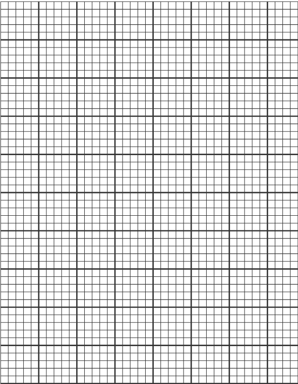

**After Part 1**

13. Rinse probes and place them in tap water.
14. Rinse both beakers thoroughly with deionized water.

**Part 2: Testing Buffers (Bufferin)**

1. Add **40 mL of distilled water** to two clean 50 mL beakers.
2. Place **one Bufferin tablet** in each beaker and let it dissolve.
3. Repeat the same procedure as in Part 1 (steps 1–13).

**Table 2: Buffered Solution (Bufferin)**

| **Total Drops Added** | **pH (Acid - Beaker A)** | **pH (Base - Beaker B)** |
| --- | --- | --- |
| **0** |  |  |
| **5** |  |  |
| **10** |  |  |
| **15** |  |  |
| **20** |  |  |
| **25** |  |  |
| **30** |  |  |

**Graph:**

Graph the data you collected.

**Title:**

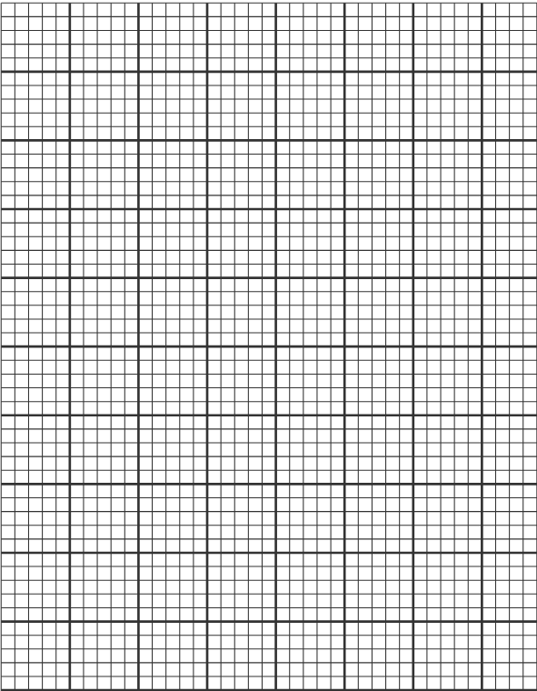

**Clean-Up**

1. Disconnect the pH probes.
2. Rinse them and return them to storage solution.
3. Clean all glassware (especially the 50 mL beakers).

## 3.4 **Activity 2: Demonstration of Capillary Action (Adhesion and Cohesion)**

In this exercise, you will observe how water can move from one container to another without direct pouring. This activity demonstrates the properties of water such as cohesion and adhesion, which allow water to travel through materials like paper towels. Over time, you will record your observations to better understand how water moves through capillary action.

1. Take two 250 ml beakers and put them side by side.
2. Fill one with water. Keep the second empty.
3. Take a piece of paper towel and fold it lengthwise in the middle a few times to get a thin strip. Fold it in the middle to make a V shape.
4. Dip one end of the paper towel strip into the empty beaker and the other end into the beaker full of water. Allow this to sit until the end of the lab period. Check the beakers every 60 mins and make observations. Record your observations below.

**Table 3 (Paper Towel Water Movement Observations):**  
A table for recording observations during an experiment where a paper towel connects two beakers, one with water and one empty. Students note changes over time, such as water movement and levels in each beaker, at regular intervals.

| **Elapsed Time** **(in minutes)** | **Observations** |
| --- | --- |
| 0 |  |
| 60 |  |
| 120 |  |

## 3.5 **Activity 3: Demonstration of Surface Tension (Adhesion and Cohesion)**

In this exercise, you will investigate the property of surface tension in water. Surface tension is caused by hydrogen bonding between water molecules, creating a thin “skin” at the surface. By observing how a paperclip floats and how detergent affects this behavior, you will better understand how intermolecular forces influence the properties of water.

1. Fill a culture dish halfway with water. Float a small paperclip on the surface of the water. This requires careful placement of the paperclips to avoid breaking the surface tension of the water.
2. Use a dropper to carefully deposit a drop of water near the floating paperclips. Record your observations.
3. Next, deposit several drops of liquid detergent near the floating paperclips. After applying the detergent, try to float another paperclip. The detergent disrupts the hydrogen bonds in water. Record your observations below.

> **Table 4 (Detergent and Surface Tension Observations):**

> A table for recording observations during an experiment where detergent is added to water with floating paperclips. Students note changes after the detergent disrupts hydrogen bonding, such as paperclips sinking and differences in surface tension.

| **Dropper contents** | **Did it cause the paperclip to sink?** | **Did this substance break the surface tension?** |
| --- | --- | --- |
| Water |  |  |
| Detergent |  |  |

## 3.6 **Activity 4: Building Models**

In this activity, you will explore how molecules are represented using molecular, structural, and abbreviated structural formulas. A molecular formula, such as glycine (C₂H₅NO₂), shows the number and types of atoms present, while structural formulas display how those atoms are bonded. Abbreviated structural formulas simplify these representations by grouping atoms, making complex molecules easier to visualize.

You will use a molecular model kit to build three-dimensional representations of molecules, helping you understand how atoms connect through covalent bonds. As you construct models, you will also observe how the same molecular formula can form different structures, known as isomers. Additionally, you will examine how chemical reactions involve breaking and forming covalent bonds to create new products.

1. Look at the four most common spheres and fill out which element they represent and how many bonds they can make in the table below.

> **Table 5 (Element Spheres and Bonding):**  
> A table for identifying common elements shown as spheres in molecular models, with columns to list each element and the number of bonds it typically forms.

| **Sphere color** | **Element** | **# of bonds it forms** |
| --- | --- | --- |
| black |  |  |
| white |  |  |
| red |  |  |
| blue |  |  |

2. Build a molecular model for each molecule listed in the table below. Use the molecular formula to collect the correct spheres first, then put them together so that every hole is filled with a bond. Have your instructor verify your models Write the structural formula from the model you built in the table below. *Hint: some of these molecules may include double or triple bonds*

> **Table 6 (Molecular Model Building Activity):**  
> A table for recording molecular model results, where students build each molecule using spheres and bonds, then write the corresponding structural formula based on the completed model.

| **Molecule** | **Molecular Formula** | **Structural Formula** |
| --- | --- | --- |
| Methane | CH₄ |  |
| Ethane | C₂H₆ |  |
| Ethene | C₂H₄ |  |
| Methanol | CH₄O |  |
| Formaldehyde | CH₂O |  |
| Acetone (*contains a carbonyl group at a ketone position between two methyl groups*) | C₃H₆O |  |
| Glycine (a *2-carbon compound; contains an amino and a carboxyl group on each end*) | C₂H₅NO₂ |  |

> Several functional groups are commonly found in organic molecules. Using the table below, build a molecular model for each listed functional group. Then, record the corresponding structural formula for each model you construct. Refer to pages 47–49 of your textbook for guidance on the shapes and characteristic properties of these functional groups.

> **Table 7 (Functional Groups Molecular Models):**  
> A table for recording common functional groups in organic molecules, where students build each group using molecular models and then write the corresponding structural formula, with dashes indicating bonds attached to a carbon atom.

[output not shown]

> **Table 8 (Determining Molecular Formulas):**  
> A table where students determine and record the molecular formulas of molecules based on given abbreviated structural formulas, with ethanol provided as an example.

Abbreviated structural formula

Molecular formula

Abbreviated structural formula

Molecular formula

CH₃-CH₂-OH

C₂H₆O

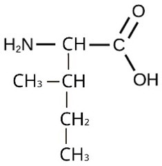

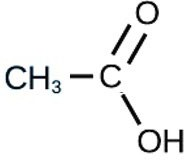

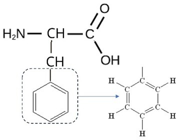

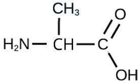

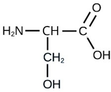

4. Create two different models which both have the molecular formula C₂H₆O. Draw the structural formula of each in the table below.

> **Table 9 (Isomers of C₂H₆O):**  
> A table where students draw and compare two different structural formulas for molecules with the same molecular formula (C₂H₆O), illustrating that the same formula can produce different structures (isomers).

| **Molecule** | **Molecular Formula** | **Structural formula** |
| --- | --- | --- |
| Ethanol *(Start by making a hydroxyl group.* |  |  |
| Dimethyl ether *(Start by making two methyl groups)* *Hint: from the name of this molecule, which functional group must this molecule have?* |  |  |

> Chemical reactions involve the breaking and forming of bonds. In this exercise, you will use molecular models to simulate these processes by modeling the formation of urea from ammonia

> Follow the steps below to construct each molecule, determine its structural formula, and identify whether it is a reactant or a product in the reaction.
1. Build two ammonia (NH₃) molecules and one carbon dioxide (CO₂) molecule.
2. Take one hydrogen (H) from each NH₃ and set them aside, these will be part of water.
3. Take one oxygen (O), and two rods from the CO₂ model, combine these with the H from step b to make water.
4. Combine the remaining molecules to construct Urea.

**Table 10 (Reactants and Products—Modeling Reaction):**  
A table for recording molecular structures and identifying whether each is a reactant or product in a model activity. Students build ammonia and carbon dioxide molecules, rearrange atoms to form water, and combine remaining atoms to form urea, then record the structural formulas and classify each substance accordingly.

| **Molecule** | **Product or Reactant?** | **Structural formula** |
| --- | --- | --- |
| Ammonia |  |  |
| Carbon dioxide |  |  |
| Urea |  |  |
| Water |  |  |

## 3.7 **Post-Lab Activities**

**Check Your Understanding (Concept Questions)**

1. Why are carbon-based molecules so diverse?
2. How does molecular shape impact function?
3. Why is polarity critical for biological systems?
4. What would happen if water had low surface tension?
5. Why is hydrogen bonding essential in biology?
6. Why must blood pH stay within a narrow range?
7. How do buffers prevent drastic pH changes?
8. What is the significance of isomers in biology?
9. How do structure and function relate in molecules?
10. Why are covalent bonds important in organic chemistry?